# KTN - Boardriders

## Market basket analysis

> - identifies the strength of association between pairs of products purchased together
> - identify patterns of co-occurrence, two or more things take place together

> > In essence it generates if -> then scenario's

#### Components of algorithm

Support

Confidence

Lift

##### A note on the metrics

[figure not shown]

Contains antecedents and consequents, both of which are part of an itemset

Implication here is co-occurence not causality

#### Support

How frequent is an itemset in all transactions

Used to identify rules worth analysing further

> $$ Support(X \cap Y) = \frac{Frequency(X \cap Y)}{N (totaltransactions)} $$

##### Example

[figure not shown]

#### Confidence

the likeliness of consequent occuring when antecedent is present

> $$ Confidence(X \cap Y) = \frac{Frequency(X \cap Y)}{Frequency(X)} $$

##### Example

[figure not shown]

Confidence(Toothbrush&Milk) = 10/14 = 0.7

Probability of having milk on the cart with the knowledge that toothbrush is present 70%

Can be misleading as we can see that there is a weak association

#### Lift

Lift controls for the support (frequency) of consequent while calculating the conditional probability of occurrence of Y given X

> $$ Lift(X \cap Y) = \frac{Support(X \cap Y)}{Support(Y)} $$

> more then 1: itemset more likely to be bought together

> 1: no association

> less then 1: less likely to be bought together

##### Example

[figure not shown]

Probability of having milk on the cart with the knowledge that toothbrush is present 70%

Consider the probability of having milk on the cart without any knowledge about toothbrush: 80/100 = 80%

having toothbrush on the cart actually reduces the probability of having milk on the cart to 0.7 from 0.8

Lift(Toothbrush&Milk) = 0.7/0.8 = 0.87

A value of lift less than 1 shows that having toothbrush on the cart does not increase the chances of occurrence of milk on the cart in spite of the rule showing a high confidence value

### Dataset of orders for unidentified e-com store

#### Preprocessing

```python
df_fr = df[df['Country'] =="France"]
df_fr.head()
```

|  | InvoiceNo | StockCode | Description | Quantity | InvoiceDate | UnitPrice | CustomerID | Country |
| --- | --- | --- | --- | --- | --- | --- | --- | --- |
| 26 | 536370 | 22728 | ALARM CLOCK BAKELIKE PINK | 24 | 12/1/2010 8:45 | 3.75 | 12583.0 | France |
| 27 | 536370 | 22727 | ALARM CLOCK BAKELIKE RED | 24 | 12/1/2010 8:45 | 3.75 | 12583.0 | France |
| 28 | 536370 | 22726 | ALARM CLOCK BAKELIKE GREEN | 12 | 12/1/2010 8:45 | 3.75 | 12583.0 | France |
| 29 | 536370 | 21724 | PANDA AND BUNNIES STICKER SHEET | 12 | 12/1/2010 8:45 | 0.85 | 12583.0 | France |
| 30 | 536370 | 21883 | STARS GIFT TAPE | 24 | 12/1/2010 8:45 | 0.65 | 12583.0 | France |

```python
print(f"Total # of unique orders {len(df_fr['InvoiceNo'].unique())}")
print(f"Total # of unique references {len(df_fr['StockCode'].unique())}")
```

```
Total # of unique orders 387
Total # of unique references 1541
```

```python
basket_France = basket_France.applymap(encode_units)
basket_France.head()
```

| StockCode InvoiceNo | 10002 | 10120 | 10125 | 10135 | 11001 | 15036 | 15039 | 15044C | 15056BL | 15056N | ... | 90030B | 90030C | 90031 | 90099 | 90184B | 90184C | 90201B | 90201C | C2 | M |
| --- | --- | --- | --- | --- | --- | --- | --- | --- | --- | --- | --- | --- | --- | --- | --- | --- | --- | --- | --- | --- | --- |
| 536370 | 1 | 0 | 0 | 0 | 0 | 0 | 0 | 0 | 0 | 0 | ... | 0 | 0 | 0 | 0 | 0 | 0 | 0 | 0 | 0 | 0 |
| 536852 | 0 | 0 | 0 | 0 | 0 | 0 | 0 | 0 | 0 | 0 | ... | 0 | 0 | 0 | 0 | 0 | 0 | 0 | 0 | 0 | 0 |
| 536974 | 0 | 0 | 0 | 0 | 0 | 0 | 0 | 0 | 1 | 0 | ... | 0 | 0 | 0 | 0 | 0 | 0 | 0 | 0 | 0 | 0 |
| 537065 | 0 | 0 | 0 | 0 | 0 | 0 | 0 | 0 | 0 | 0 | ... | 0 | 0 | 0 | 0 | 0 | 0 | 0 | 0 | 0 | 0 |
| 537463 | 0 | 0 | 0 | 0 | 0 | 0 | 0 | 0 | 0 | 0 | ... | 0 | 0 | 0 | 0 | 0 | 0 | 0 | 0 | 0 | 0 |

5 rows × 1541 columns

```python
rules.head()
```

|  | antecedents | consequents | antecedent support | consequent support | support | confidence | lift | leverage | conviction |
| --- | --- | --- | --- | --- | --- | --- | --- | --- | --- |
| 69 | (21086, 21080) | (21094) | 0.103359 | 0.129199 | 0.100775 | 0.975000 | 7.546500 | 0.087421 | 34.832041 |
| 70 | (21080, 21094) | (21086) | 0.103359 | 0.139535 | 0.100775 | 0.975000 | 6.987500 | 0.086353 | 34.418605 |
| 25 | (21094) | (21086) | 0.129199 | 0.139535 | 0.124031 | 0.960000 | 6.880000 | 0.106003 | 21.511628 |
| 66 | (23256) | (23254) | 0.069767 | 0.072351 | 0.064599 | 0.925926 | 12.797619 | 0.059552 | 12.523256 |
| 34 | (21988) | (21987) | 0.056848 | 0.064599 | 0.051680 | 0.909091 | 14.072727 | 0.048007 | 10.289406 |

#### Simulation

#### Random Allocation

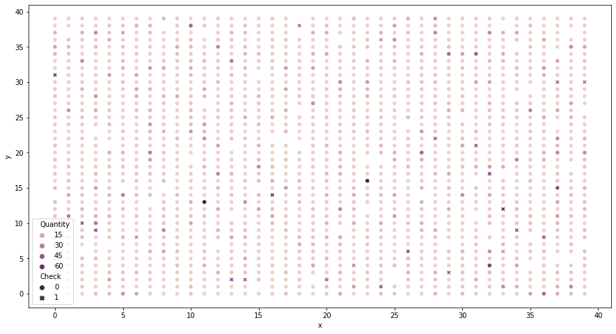

```python
plt.figure(figsize=(15,8))
sns.scatterplot(data=wh_random, x='x', y='y', hue='Quantity', style='Check')
```

#### Support Allocation

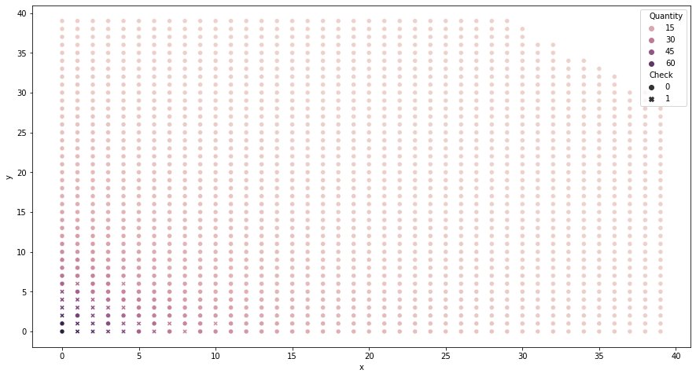

```python
plt.figure(figsize=(15,8))
sns.scatterplot(data=wh_support, x='x', y='y', hue='Quantity', style='Check')
```

#### Rules Allocation

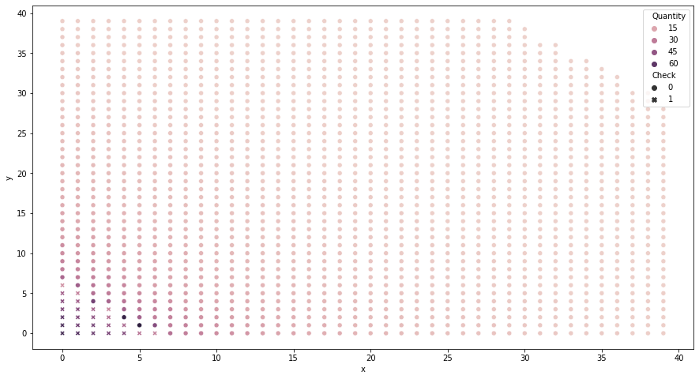

```python
plt.figure(figsize=(15,8))
sns.scatterplot(data=wh_basket, x='x', y='y', hue='Quantity', style='Check')
```

#### Simulation walking distance

```python
print(f"Total distance Random Allocation: {sum(ls_random)}")
print(f"Total distance Support Allocation: {sum(ls_support)}")
print(f"Total distance Rules Allocation: {sum(ls_basket)}")
```

```
Total distance Random Allocation: 177790
Total distance Support Allocation: 120324
Total distance Rules Allocation: 121152
```

```python
print(f"Difference Random vs Support {round(sum(ls_support)/sum(ls_random) - 1,2)*100}%")
print(f"Difference Support vs Rules {round(sum(ls_basket)/sum(ls_support) - 1,2)*100}%")
```

```
Difference Random vs Support -32.0%
Difference Support vs Rules 1.0%
```

### Goals KTN

1. Run initial apriori analysis on last season(s)
2. Model warehouse as coordinate-points
3. Run simulations to see which split could have least walking-distance
4. Develop algo to assign locations and organise moves